# Data Science 2: Advanced Topics in Data Science

[figure not shown]

## Final Project: Sentiment Analysis from Audio Data

**Harvard University**  
**Spring 2024**  
**Team 26**: Vincent Hock, Conrad Hock, Cooper Bosch, Tomas Arevalo, Jake Pappo

## **Notebook Contents**

- **Setup**
- **Problem Statement**
- **Data Description & Preprocessing**
- **EDA**
- **Baseline Model**
- **Final Models**
  - **FFNN / CNN**
  - **LSTM**
  - **Transformer**
  - **SOTA**
- **Discussion**

## **Setup**

Load libraries, install dependencies, and configure formatting

```python
# HTML Formatting
import requests
from IPython.core.display import HTML
styles = requests.get(
    "https://raw.githubusercontent.com/Harvard-IACS/2018-CS109A/master/"
    "content/styles/cs109.css"
).text
HTML(styles);
```

One library our code relies on heavily is the librosa package. It is a library specifically designed for audio and music analysis, and provided us with the functionality to convert our signal data into Mel spectrograms through fast fourier transforms.

We also use the transformers module from Huggingface, which is key to loading pretrained models and training them. The resulting model from Wav2Vec2 (described below) was primarily built in pytorch, so we also installed torchinfo as a tool to summarize model features.

```python
# Install dependencies
# !pip install librosa
# !pip install evaluate
# !pip install transformers
# !pip install torchinfo
```

```python
# Import libraries
import re
import time
import os
import wave
import scipy
import librosa
import evaluate
import matplotlib.pyplot as plt
import numpy as np
import pandas as pd
import tensorflow as tf
import csv

from tensorflow import keras
from keras.models import Model, Sequential, load_model
from keras import layers
from keras import losses
from keras import optimizers
from keras.callbacks import EarlyStopping, LambdaCallback, ModelCheckpoint
from tensorflow.keras import layers
from keras.layers import Input, Embedding, SimpleRNN, GRU, LSTM, TimeDistributed, Bidirectional, Dense
from keras.layers import  BatchNormalization, Activation, Dropout, GaussianNoise, LayerNormalization
from keras.layers import Conv2D, MaxPooling2D, Flatten, Layer
from keras.regularizers import L1
from keras.utils import to_categorical
from tensorflow.keras.preprocessing.sequence import pad_sequences

from sklearn.decomposition import PCA
from sklearn.metrics import f1_score
from sklearn.metrics import confusion_matrix, accuracy_score, ConfusionMatrixDisplay
from sklearn.model_selection import train_test_split
from sklearn.utils.class_weight import compute_class_weight
from sklearn.linear_model import LogisticRegression
from sklearn.preprocessing import StandardScaler

from IPython.display import Audio

from datasets import Dataset
from datasets import Audio as AudioCast
from transformers import AutoFeatureExtractor, AutoModelForAudioClassification, TrainingArguments, Trainer
from torchinfo import summary
import seaborn as sns
```

[output not shown]

```python
path = os.getcwd() + '/Audio_Speech_Actors_01-24'
path
```

```
'/home/u_388354/project/Audio_Speech_Actors_01-24'
```

## **Problem Statement**

The aim of this project is to develop a robust emotion classification system capable of accurately identifying the emotional state of a speaker based on an audio clip of their speech. Emotion classification from audio presents a considerable challenge due to the inherent variability in speech patterns, pitch & tones, and the subjective nature of emotions. But the benenfits of such a model are apparent; its depolyment in voice assistants or sentiment analysis tools would enable tiMely and accurate emotion recognition from audio inputs, fostering advancements in human-computer interaction and affective computing.

We will explore a number of different model architectures to accurately classify each audio clip into 1 of 8 different emotional tones, and weigh the advantages and drawbacks of each approach to better understand the difficulties and opportunities associated with audio sentiment analysis.

## **Data Preprocessing**

#### **Data Description**

Our data will be coming from the Ryerson Audio-Visual Database of Emotional Speech and Song (RAVDESS). This database contains audios from 24 professional voice actors, 12 female and 12 male, each of whom, as stated by RAVDESS, have a “neutral North American accent”. There are two phrases which they all say. The first phrase is “Dogs are sitting by the door” and the other is “Kids are talking by the door”. Every actor says each phrase in 8 different emotional tones: “neutral”, “calm“, “happy“, “sad“, “angry“, “fearful“, “disgust“, “surprised“, and each tone has an emotional intensity: “normal“, “strong“. It is important to note that there is no strong intensity for the “neutral” emotion. Next, for all phrases each actor says it twice for repetition. Thus, every actor has 60 speech recordings in total. Although we only plan to use the speech audio data, RAVDESS also makes song audio and video available to us as well, but we don’t plan to use them.

There are 1440 audio samples, with an average of 177632 data points per sample. We don’t have many samples, but we do have a lot of data per sample. Thus, we will need to perform per-sample dimensionality reduction, but we will need to use data augmentation to generate more samples.

#### **Summary of Data**

After the preprocessing outlined in Milestone 2, there are 1440 samples, each with a stream of 253125 integer values. These samples are each pre-padded with zeros to standardize their length. The number 253125 as it was the smallest number larger than the maximum sample length that was divisible by what we deemed to be sufficient factors: 1, 3, 5, 9, 15, 25, 27, …. This will be useful in reducing the dimensionality of the data through averaging consecutive points or selecting every nth value, as well as in our potential exploration of Fourier transforms for feature selection.

For ease of use, we have constructed a Pandas DataFrame containing, for each audio sample, the corresponding Emotion, Intensity, Statement, Repetition, Actor, Gender of Actor, Frame Rate, and Number of Frames before padding, as well as the np.array containing the data stream itself.

#### **Data Preprocessing**

```python
def read_wav_file(file_path):
    with wave.open(file_path, 'rb') as wav_file:
        num_channels = wav_file.getnchannels()
        sample_width = wav_file.getsampwidth()
        frame_rate = wav_file.getframerate()
        num_frames = wav_file.getnframes()

        # Read the raw audio data
        raw_data = wav_file.readframes(num_frames)

    # Convert the raw audio data to a numpy array
    if sample_width == 2:
        data_type = np.int16
    elif sample_width == 4:
        data_type = np.int32
    else:
        raise ValueError("Unsupported sample width")

    audio_data = np.frombuffer(raw_data, dtype=data_type)

    # Reshape the numpy array if there are multiple channels
    if num_channels > 1:
        audio_data = audio_data.reshape(-1, num_channels)

    return audio_data, frame_rate
```

```python
wav_paths = []

# os.walk gives files recursively
for root, dirs, files in os.walk(os.getcwd()):
    for file in files:
        # ignore .DS_Store
        if file.endswith('.wav'):
            wav_path = os.path.join(root, file)
            wav_paths.append(wav_path)
```

```python
# Pick padding length that enables prime factorization
MAX_LEN = 3**4 * 5**5
```

```python
# Helper function for info, can be made categorical instead of numeric
id2label = {
                0: 'neutral',
                1: 'calm',
                2: 'happy',
                3: 'sad',
                4: 'angry',
                5: 'fearful',
                6: 'disgust',
                7: 'surprised'
              }

label2id = {v: k for k, v in id2label.items()}

def info_dict(path):
    dict = {}
    emotion_number = int(path[-18:-16]) - 1
    dict['Emotion_Number'] = emotion_number
    dict['Emotion'] = id2label[emotion_number]
    dict['Intensity'] = int(path[-15:-13])
    statement_number = int(path[-12:-10])
    dict['Statement_Number'] = statement_number
    dict['Statement'] = ['OOB', 'Kids', 'Dogs'][statement_number]
    dict['Repetition'] = int(path[-9:-7])
    dict['Actor'] = int(path[-6:-4])   #0 = female, 1 = male
    gn = int((int(path[-6:-4]) % 2 == 1))
    dict['Gender_Number'] = int((int(path[-6:-4]) % 2 == 1))
    dict['Gender'] = ['Female', 'Male'][gn]
    return dict
```

```python
data_list = []

for path in wav_paths:
    # helper function above
    dict = info_dict(path)
    data, fr = read_wav_file(path)
    dict['Frame_Rate'] = fr

    # Length without padding
    dict['Num_Frames'] = len(data)

    # Check for 5 cases where data is doubled
    if len(data.shape) != 1:
        data = data.T[0]

    # Do padding
    new_data = np.pad(data, (MAX_LEN - len(data), 0), 'constant')

    dict['Data'] = new_data
    data_list.append(dict)

df = pd.DataFrame(data_list)
```

```python
df.head(3)
```

|  | Emotion_Number | Emotion | Intensity | Statement_Number | Statement | Repetition | Actor | Gender_Number | Gender | Frame_Rate | Num_Frames | Data |
| --- | --- | --- | --- | --- | --- | --- | --- | --- | --- | --- | --- | --- |
| 0 | 5 | fearful | 1 | 2 | Dogs | 1 | 17 | 1 | Male | 48000 | 169770 | [0, 0, 0, 0, 0, 0, 0, 0, 0, 0, 0, 0, 0, 0, 0, ... |
| 1 | 3 | sad | 2 | 2 | Dogs | 2 | 17 | 1 | Male | 48000 | 171371 | [0, 0, 0, 0, 0, 0, 0, 0, 0, 0, 0, 0, 0, 0, 0, ... |
| 2 | 4 | angry | 2 | 1 | Kids | 2 | 17 | 1 | Male | 48000 | 179379 | [0, 0, 0, 0, 0, 0, 0, 0, 0, 0, 0, 0, 0, 0, 0, ... |

```python
df.info()
```

```
<class 'pandas.core.frame.DataFrame'>
RangeIndex: 1440 entries, 0 to 1439
Data columns (total 12 columns):
 #   Column            Non-Null Count  Dtype
---  ------            --------------  -----
 0   Emotion_Number    1440 non-null   int64
 1   Emotion           1440 non-null   object
 2   Intensity         1440 non-null   int64
 3   Statement_Number  1440 non-null   int64
 4   Statement         1440 non-null   object
 5   Repetition        1440 non-null   int64
 6   Actor             1440 non-null   int64
 7   Gender_Number     1440 non-null   int64
 8   Gender            1440 non-null   object
 9   Frame_Rate        1440 non-null   int64
 10  Num_Frames        1440 non-null   int64
 11  Data              1440 non-null   object
dtypes: int64(8), object(4)
memory usage: 135.1+ KB
```

## **EDA**

### **Visualize Audio Sample**

```python
# Example usage
test_path = wav_paths[100]

file_path = test_path
audio_data, frame_rate = read_wav_file(file_path)
print("Audio data shape:", audio_data.shape)
print("Frame rate:", frame_rate)
audio_data
```

```
Audio data shape: (166566,)
Frame rate: 48000
```

```
array([ 1,  2,  2, ..., -5, -4, -5], dtype=int16)
```

```python
Audio(audio_data, rate=frame_rate)
```

[interactive chart not shown]

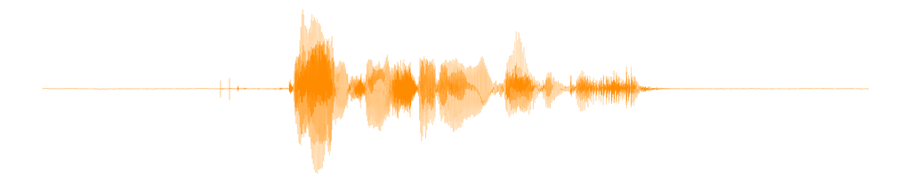

```python
ms = range(audio_data.shape[0])
fig, ax = plt.subplots(figsize=(100, 20))
ax.plot(ms, audio_data, c='darkorange')
ax.axis('off')
plt.show()
```

### **Length Variation**

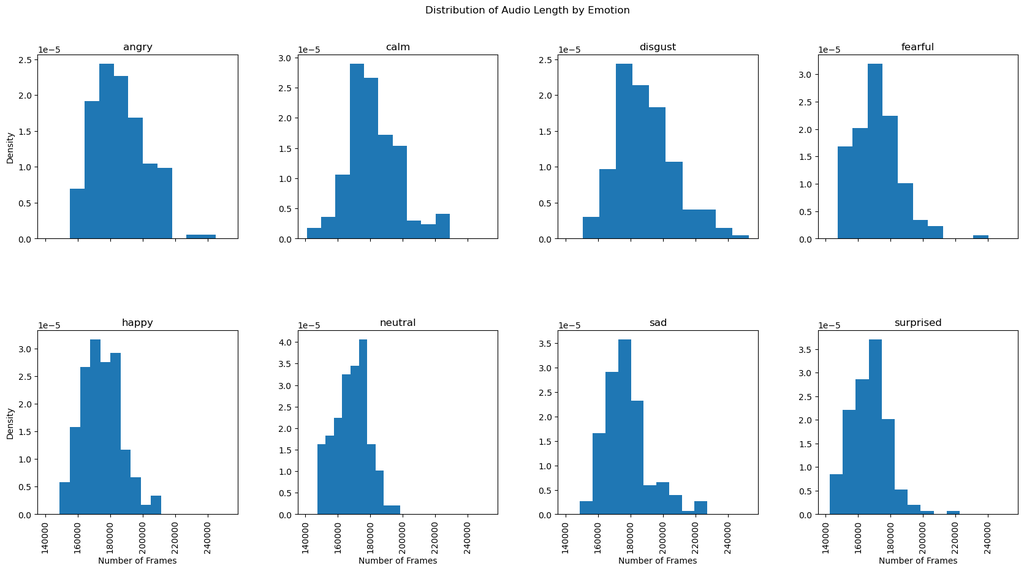

```python
histos=df['Num_Frames'].hist(by=df['Emotion'], sharex=True, figsize=(20,10), layout=(2,4), density=True)

histos[0,0].set_ylabel('Density')
histos[1,0].set_ylabel('Density')

histos[1,0].set_xlabel('Number of Frames')
histos[1,1].set_xlabel('Number of Frames')
histos[1,2].set_xlabel('Number of Frames')
histos[1,3].set_xlabel('Number of Frames')

plt.suptitle('Distribution of Audio Length by Emotion');
```

The distribution of audio lengths appears to be largely similar in shape among various emotions, with disgust showing more variation than the others.

```python
mean_lens=df[['Emotion_Number', 'Num_Frames']].groupby(by=['Emotion_Number']).mean()['Num_Frames']
sd_lens=df[['Emotion_Number', 'Num_Frames']].groupby(by=['Emotion_Number']).std()['Num_Frames']
xs=list(id2label.values())
```

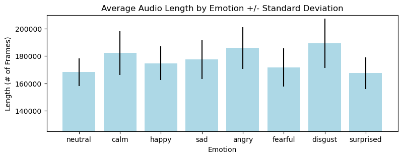

```python
fig,ax=plt.subplots(1,1,figsize=(9,3))
plt.bar(height=mean_lens, x=xs,  yerr=sd_lens, color='lightblue')
plt.ylim(125000, 210000)
plt.xlabel('Emotion')
plt.ylabel('Length (# of Frames)')
plt.title('Average Audio Length by Emotion +/- Standard Deviation');
```

Different emotions exhibit variable average number of frames in their respective recordings. Nevertheless, it appears that the variation of recording lengths within each emotion is greater than the variation among each emotion’s average recording lengths.

### **Amplitude Variation**

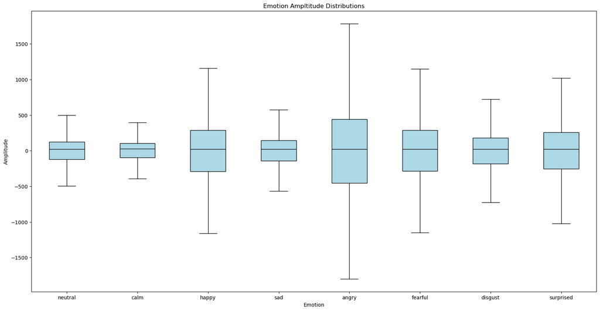

```python
emotions = range(0, 8)

# Create subplots
fig, ax = plt.subplots(figsize=(20, 10))

# Position for each box plot
positions = np.arange(1, len(emotions) + 1)

# Iterate over emotions
box_data = []
for i, emotion in enumerate(emotions):
    # Filter the DataFrame
    filtered_df = df[(df['Emotion_Number'] == emotion)]

    # Combine the data into a single array
    vals = np.concatenate(filtered_df['Data'].values)
    for j in range(-20, 21):
        vals = vals[vals != j]

    box_data.append(vals)

# Create the box plot
boxplot = ax.boxplot(box_data, positions=positions, vert=True, patch_artist=True, showfliers=False)

# Add labels and grid
ax.set_ylabel('Amplitude')
ax.set_xlabel('Emotion')
ax.set_xticklabels([id2label[emotion] for emotion in emotions])
ax.set_title("Emotion Ampltitude Distributions")

# Customize colors
for patch in boxplot['boxes']:
    patch.set_facecolor('lightblue')

for median in boxplot['medians']:
    median.set(color='black')

plt.show()
```

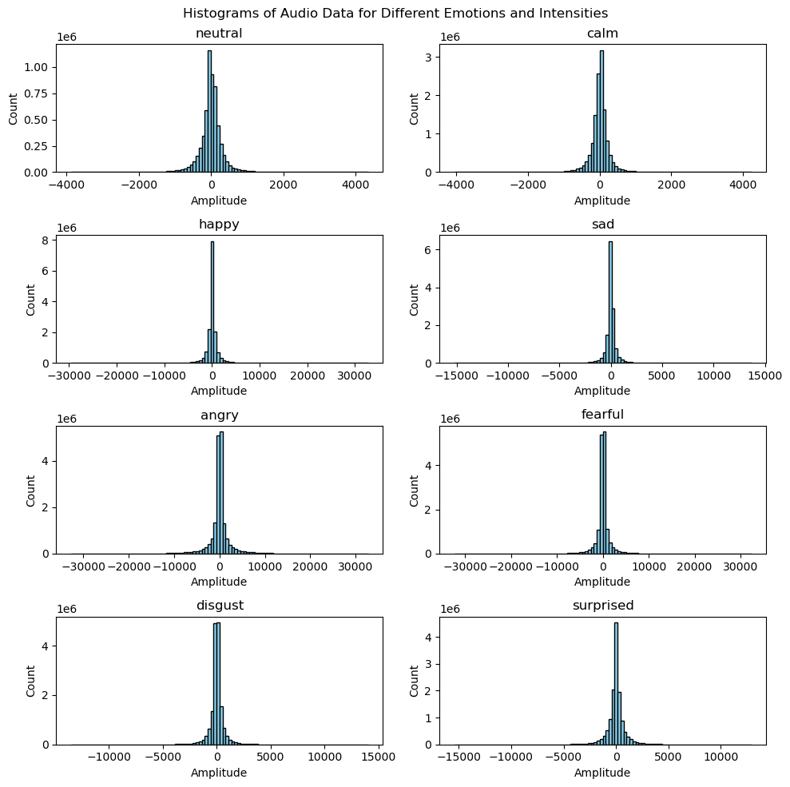

```python
# Create subplots
fig, axs = plt.subplots(4, 2, figsize=(10, 10))
fig.suptitle('Histograms of Audio Data for Different Emotions and Intensities')

# Iterate over emotions
for i, emotion in enumerate(emotions):
    # Calculate subplot position
    row = i // 2
    col = i % 2

    # Filter the DataFrame
    filtered_df = df[(df['Emotion_Number'] == emotion)]

    # Combine the data into a single array
    vals = np.concatenate(filtered_df['Data'].values)
    for j in range(-20, 21):
        vals = vals[vals != j]

    # Plot the histogram
    axs[row, col].hist(vals, bins=100, color='skyblue', edgecolor='black')
    axs[row, col].set_title(id2label[emotion])
    axs[row, col].set_xlabel('Amplitude')
    axs[row, col].set_ylabel('Count')

# Adjust layout
plt.tight_layout()
plt.show()
```

### **Standard Deviation of $\Delta$amplitude**

```python
data_array = np.array(list(df['Data']))
data_averages = np.mean(data_array.reshape(1440, int(data_array.shape[1]/5), 5), axis=-1)
# Make an array of the deltas between time steps
data_differences = data_averages[:,1:] - data_averages[:,:-1]
# Store the standard deviations of this differences
stds = np.std(data_differences, axis = 1)
df['Change_Deviation'] = list(stds)
```

```python
# Can see the more passionate emotions have higher variance in change
df[['Change_Deviation','Emotion']].groupby(['Emotion']).mean()
```

| Emotion | Change_Deviation |
| --- | --- |
| angry | 899.235758 |
| calm | 50.527442 |
| disgust | 167.523488 |
| fearful | 446.503306 |
| happy | 339.889837 |
| neutral | 68.235074 |
| sad | 118.996169 |
| surprised | 198.101180 |

### **Summary of Findings**

Overall, it appears that emotions like happy, fearful, and angry display much greater variation in signal amplitude than emotions like neutral and calm. Emotions also display modest differences in the lengths of their audio signal. On average, disgust and anger, for example, appear to be more drawn out neutral, fearful, and surprised

## **Baseline Model**

### **Baseline Evaluation**

#### **Data Collection Pipeline & Tools**

```python
length = len(df)
frame_rate = 48000
def get_sample():
    is_neutral = True
    # Never plays neutral audio
    while(is_neutral):
        rand_index = np.random.randint(0,length)
        audio_data = df.iloc[rand_index]['Data']
        true_val = df.iloc[rand_index]['Emotion']
        is_neutral = (true_val == 'neutral')
    return (Audio(audio_data, rate = frame_rate, autoplay = True), rand_index, true_val)

# Will delete the csv, do not run
def reset_csv(file_name):
    with open(file_name, 'w', newline='') as csvfile:
        fieldnames = ['index', 'true', 'pred']
        writer = csv.DictWriter(csvfile, fieldnames=fieldnames)
        writer.writeheader()

def add_to_csv(file_name, id, true, guess):
    with open(file_name, 'a', newline='') as csvfile:
        fieldnames = ['index', 'true', 'pred']
        writer = csv.DictWriter(csvfile, fieldnames=fieldnames)

        writer.writerow({'index' : id, 'true' : true, 'pred' : guess})
```

```python
audio, id, true_val = get_sample()
display(audio)
```

[interactive chart not shown]

```python
for i in range(1,9):
    print(i, id2label[i-1])
```

```
1 neutral
2 calm
3 happy
4 sad
5 angry
6 fearful
7 disgust
8 surprised
```

```python
guess = 4
add_to_csv('baseline.csv', id, true_val, guess)
```

#### **Data Collection Results**

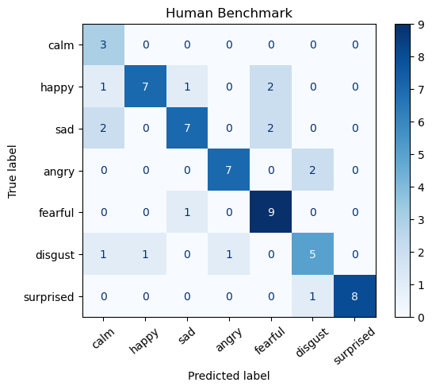

```
Accuracy of Human Model: 0.7541
```

```python
baseline_df = pd.read_csv('baseline.csv')
baseline_df['pred'] = baseline_df['pred'] - 1
baseline_df['pred_emotion'] = baseline_df['pred'].apply(lambda x: id2label[x])
baseline_df['true_num'] = baseline_df['true'].apply(lambda x: label2id[x])

y_preds = list(baseline_df['pred'])

y_test = list(baseline_df['true_num'])

emotion_names = list(id2label.values())
ConfusionMatrixDisplay(confusion_matrix(y_test, y_preds), display_labels = emotion_names[1:]).plot(cmap='Blues', xticks_rotation = 40)
plt.title('Human Benchmark')
plt.show()

print(f'\nAccuracy of Human Model: {np.round(accuracy_score(y_preds,y_test), 5)}')
```

### **Baseline Logistic Regression**

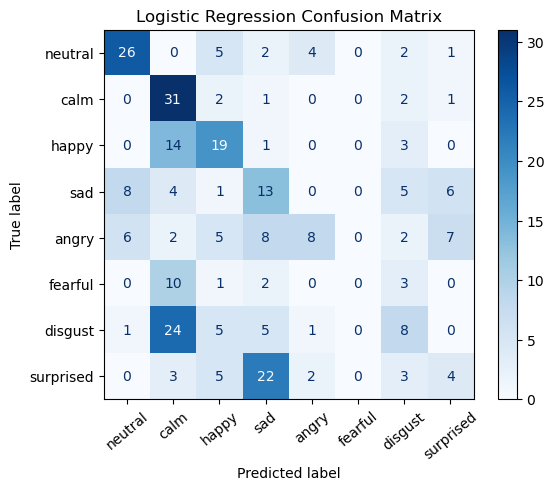

```
Accuracy of Baseline Model: 0.37847
```

```python
# Baseline model uses change deviation and the length of the clip in logistic regression
import warnings
warnings.filterwarnings("ignore")

X = df[['Change_Deviation', 'Num_Frames']]
y = df['Emotion']
X_train, X_test, y_train, y_test = train_test_split(X, y, test_size=0.2, random_state = 1777)
baseline_logreg = LogisticRegression(random_state=10, max_iter=10000, multi_class='ovr').fit(X_train, y_train)
y_preds = baseline_logreg.predict(X_test)

ConfusionMatrixDisplay(confusion_matrix(y_test, y_preds), display_labels = emotion_names).plot(cmap='Blues', xticks_rotation = 40)
plt.title('Logistic Regression Confusion Matrix')
plt.show()

print(f'\nAccuracy of Baseline Model: {np.round(accuracy_score(y_preds,y_test), 5)}')
```

## **Final Models**

### **Modeling Preparation**

#### **Mel Spectrogram**

We make heavy use of the Mel Spectrogram transformation to preprocess our data before using the more complex models. Since the way humans process audio data is more closely related to variations in pitch, we need some way to turn our amplitude data into pitch frequencies. The fourier transform does this for us, and running an FFT algorithm on multiple small time increments turns our amplitude data into a representation of how the speaker's pitch varies over the time of the recording.

Finally, the Mel transformation puts these pitch frequencies on a log scale that gives better differentiation of pitch when specifically analyzing human speech.

```python
# Hyper parameters for Melspectrogram
sr = 48000
n_fft = 2048
hop_length = 512

def get_melspectrogram(audio, n_mels=128):
    # First make sure audio data is casted to float
    audio_as_float = audio.astype(np.float32)
    mel = librosa.feature.melspectrogram(y = audio_as_float, sr=sr, n_fft=n_fft, hop_length=hop_length, n_mels=n_mels)
    return mel

df['mel128'] = df['Data'].apply(lambda x: get_melspectrogram(x, n_mels=128))
df['mel256'] = df['Data'].apply(lambda x: get_melspectrogram(x, n_mels=256))
```

```python
# Mel-SPECTROGRAM CONVERTED DATASET
mel_128 = np.array(list(df['mel128']))
mel_256 = np.array(list(df['mel256']))
```

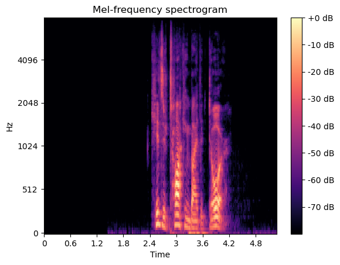

```python
# Visualize spectrogram (for 128 Mel features)
fig, ax = plt.subplots()
S_dB = librosa.power_to_db(mel_128[3], ref=np.max)
img = librosa.display.specshow(S_dB, x_axis='time',
                         y_axis='mel', sr=sr,
                         fmax=8000, ax=ax)
fig.colorbar(img, ax=ax, format='%+2.0f dB')
ax.set(title='Mel-frequency spectrogram');
```

```python
# Prepare dataset
X = mel_128
y = df['Emotion_Number'].values
```

#### **Helper Functions**

```python
def evaluate_predictions(model, model_name, X_test=X_test, y_test=y_test):
    # Get predictions
    y_pred = model.predict(X_test)
    y_pred_classes = np.argmax(y_pred, axis=1)

    # Create Confusion Matrix
    conf_matrix = confusion_matrix(y_test, y_pred_classes)
    emotion_labels = [id2label[i] for i in range(len(emotions))]
    disp = ConfusionMatrixDisplay(confusion_matrix=conf_matrix, display_labels=emotion_labels)

    # Graph Confusion Matrix
    disp.plot(cmap='Blues', xticks_rotation = 40)
    plt.title(f'{model_name} Confusion Matrix')
    plt.show()
```

```python
def plot_history(history, model_name):
    plt.figure(figsize=(12, 6))

    plt.subplot(1, 2, 1)
    best_val_acc_loc = np.argmax(history.history['val_accuracy'])
    best_val_accuracy = max(history.history['val_accuracy'])
    plt.plot(history.history['accuracy'], label='train')
    plt.plot(history.history['val_accuracy'], label='validation')
    plt.axvline(best_val_acc_loc, linestyle='--', c='k', label=("best val acc: {:.4f}".format(best_val_accuracy)))
    plt.title(f'{model_name} accuracy')
    plt.xticks(range(0, len(history.history['accuracy']), 2))
    plt.ylabel('Accuracy')
    plt.xlabel('Epoch')
    plt.legend(loc='upper left')

    plt.subplot(1, 2, 2)
    best_val_loss_loc = np.argmax(history.history['val_loss'])
    best_val_loss = max(history.history['val_loss'])
    plt.plot(history.history['loss'], label='train')
    plt.plot(history.history['val_loss'],  label='validation')
    plt.axvline(best_val_loss_loc, linestyle='--', c='k', label=("best val loss"))
    plt.title(f'{model_name} loss')
    plt.xticks(range(0, len(history.history['accuracy']), 2))
    plt.ylabel('Loss')
    plt.xlabel('Epoch')
    plt.legend(loc='upper left')

    plt.tight_layout()
    plt.show()
```

### **FFNN**

Let's start with a very simple approach; a feed forward neural network. Given the dimensionality reduction that Mel Spectrogram offers, we now have a somewhat more manageable (but still enormous) input size for densely connect layers. We'll set another baseline (this time, a neural net baseline) by simply brute force passing the Mel spectrograms into a FFNN.

#### **Data Preparation**

```python
# Prepare dataset
X_ffnn = mel_128
y = df['Emotion_Number'].values

X_train, X_test, y_train, y_test = train_test_split(X_ffnn, y, test_size=0.2, random_state=109, stratify=y)
```

#### **Build & Compile Model**

```python
input_shape = (X_train.shape[1], X_train.shape[2], 1)

n_filters = 10

kernel_regularizer = L1(l1=0.015)
bias_regularizer = L1(l1=0.015)
dropout_rate = 0.5
```

```python
inputs = Input(shape=input_shape)

# # Flatten the convolutional layers output before the fully connected layers
x = Flatten()(inputs)

# Dense layers
x = Dense(500, activation='relu', kernel_regularizer=kernel_regularizer, bias_regularizer=bias_regularizer)(x)
x = Dropout(dropout_rate)(x)
x = Dense(500, activation='relu', kernel_regularizer=kernel_regularizer, bias_regularizer=bias_regularizer)(x)
x = Dropout(dropout_rate)(x)

# Output layer
outputs = Dense(len(emotions), activation='softmax')(x)

ffnn = Model(inputs=inputs, outputs=outputs, name='ffnn')
```

[output not shown]

```python
ffnn.compile(optimizer='adam', loss='sparse_categorical_crossentropy', metrics=['accuracy'])

ffnn.summary()
```

```
Model: "ffnn"
_________________________________________________________________
 Layer (type)                Output Shape              Param #
=================================================================
 input_1 (InputLayer)        [(None, 128, 495, 1)]     0

 flatten (Flatten)           (None, 63360)             0

 dense (Dense)               (None, 500)               31680500

 dropout (Dropout)           (None, 500)               0

 dense_1 (Dense)             (None, 500)               250500

 dropout_1 (Dropout)         (None, 500)               0

 dense_2 (Dense)             (None, 8)                 4008

=================================================================
Total params: 31935008 (121.82 MB)
Trainable params: 31935008 (121.82 MB)
Non-trainable params: 0 (0.00 Byte)
_________________________________________________________________
```

[figure not shown]

We are using a very simply FFNN architecture; we'll flatten the input, and then pass it through two fully-connected Dense layers with dropout before passing it to the final output Dense layer with a softmax activation function.

#### **Train Model**

```python
early_stopping = EarlyStopping(monitor='val_accuracy', patience=10, restore_best_weights=True)

ffnn_history = ffnn.fit(X_train,
                      y_train,
                      validation_data=(X_test, y_test),
                      epochs=100,
                      batch_size=16,
                      callbacks=[early_stopping])
```

[output not shown]

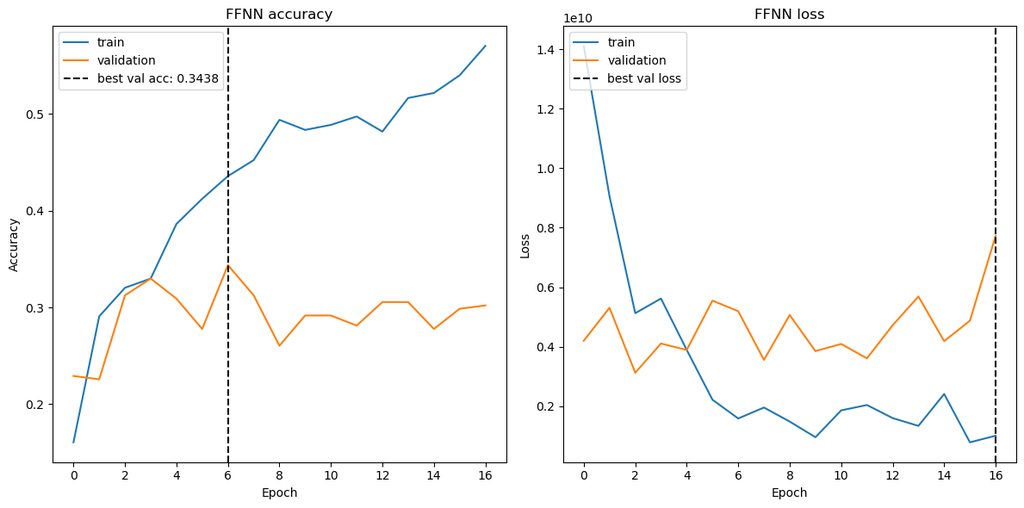

```python
plot_history(ffnn_history, 'FFNN')
```

#### **Evaluation & Analysis**

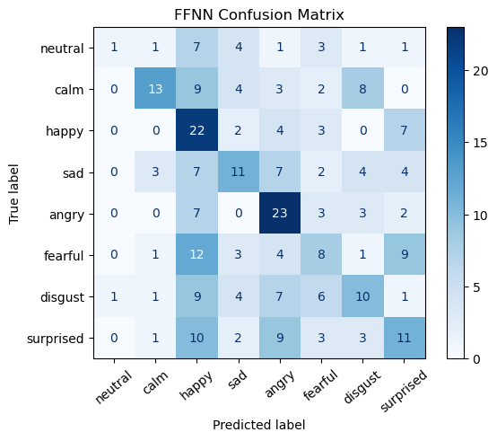

```python
evaluate_predictions(ffnn, 'FFNN', X_test=X_test, y_test=y_test)
```

### **LSTM**

As we covered in lecture, LSTMs are a type of RNN that can capture long-term dependencies in the input data, making them particularly useful for tasks involving sequential data. Thus, we believe that LSTM model architecture could be potenitially well suited for the task of sentiment analysis on our dataset due to its ability to effectively process our sequential data which comes in the form of audio samples.

Again, this is a baseline LSTM model which I dont expect to work that well, and when training, will have to finetune specific parameters and maybe even add more layers. Nonetheless, we do hope that LSTMs will perform well because our data, audio samples, are as sequential as it gets.

#### **Data Preparation**

```python
X_lstm = mel_128
y = df['Emotion_Number'].values

X_train, X_test, y_train, y_test = train_test_split(X_lstm, y, test_size=0.2, random_state=109)
```

```python
# adjust shapes so can pass in sequentially
X_train = np.transpose(X_train, (0, 2, 1))
X_test = np.transpose(X_test, (0, 2, 1))
```

#### **Build & Compile Model**

```python
lstm = Sequential([
    GaussianNoise(0.1, input_shape=(X_train.shape[1], X_train.shape[2])),
    LSTM(units=512, return_sequences=True),
    Dropout(0.2),
    LSTM(units=512),
    Dropout(0.2),
    Dense(units=64, activation='relu'),
    Dense(units=8, activation='softmax')
])

lstm.compile(optimizer='adam', loss='sparse_categorical_crossentropy', metrics=['accuracy'])

lstm.summary()
```

```
Model: "sequential_1"
_________________________________________________________________
 Layer (type)                Output Shape              Param #
=================================================================
 gaussian_noise_1 (Gaussian  (None, 495, 128)          0
 Noise)

 lstm_2 (LSTM)               (None, 495, 512)          1312768

 dropout_4 (Dropout)         (None, 495, 512)          0

 lstm_3 (LSTM)               (None, 512)               2099200

 dropout_5 (Dropout)         (None, 512)               0

 dense_5 (Dense)             (None, 64)                32832

 dense_6 (Dense)             (None, 8)                 520

=================================================================
Total params: 3445320 (13.14 MB)
Trainable params: 3445320 (13.14 MB)
Non-trainable params: 0 (0.00 Byte)
_________________________________________________________________
```

#### **Train Model**

```python
early_stopping = EarlyStopping(monitor='val_accuracy', patience=15, restore_best_weights=True)

filepath = "lstm_weights.h5"
checkpoint_callback = ModelCheckpoint(filepath,
                                      monitor="val_accuracy",
                                      save_weights_only=True,
                                      save_best_only=True,
                                      verbose=0)


lstm_history = lstm.fit(X_train,
          y_train,
          validation_data=(X_test, y_test),
          epochs=100,
          batch_size=16,
          callbacks=[early_stopping, checkpoint_callback])
```

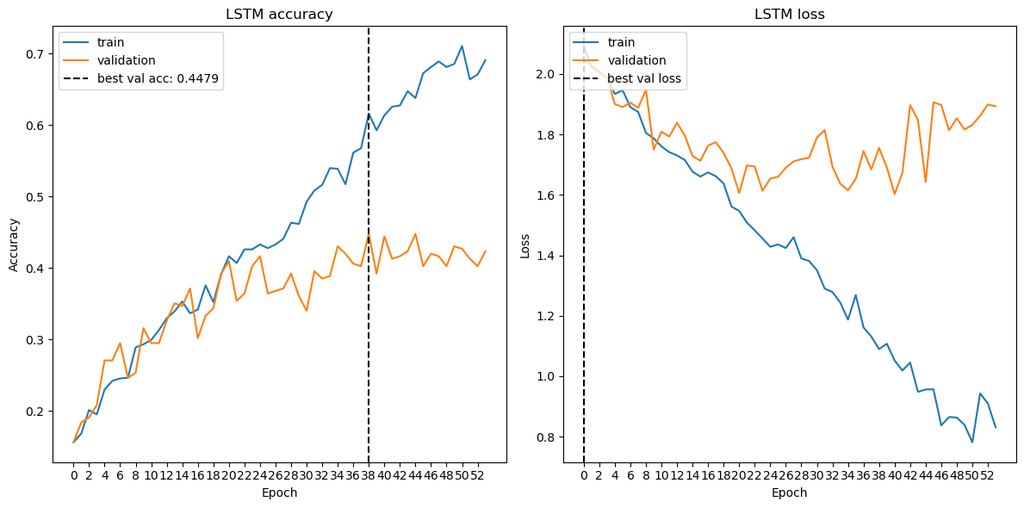

```python
plot_history(lstm_history, "LSTM")
```